# Assignment 3 - Logistic Regression

## Assignment 3 - logistic Regression

### Dipannita Banerjee

#### Bangalore Group 1

```python
import numpy as np
import pandas as pd
from sklearn.model_selection import train_test_split
import statsmodels.api as sm
import os
```

### Prepare Data Set

- Import data set
- Decide response variable - 'Survived' (already encoded in integer values)
- Drop columns 'Ticket', 'Name', 'Cabin', and 'PassengerId' as those are unnecessary for our logistic regression model
- Generate dummy code for catagorical variable .

  There are theree catagorical variables in the dataset - 'Pclass' , 'Sex' and 'Embarked'. I have created dummy code for them and drop nth column for each of them (Pclass_1,female and Embarked_C) to avoid multi-collinearity in the data set .

```python
os.chdir(r'C:/Users/IBM_ADMIN/Music/UC/Module - Machine learning\Module 3/Assignment 3')
```

```python
asg=pd.read_csv('titanic_dataset.csv')
```

```python
asg.shape
```

```
(891, 12)
```

```python
asg.count()/asg.shape[0]
```

```
PassengerId    1.000000
Survived       1.000000
Pclass         1.000000
Name           1.000000
Sex            1.000000
Age            0.801347
SibSp          1.000000
Parch          1.000000
Ticket         1.000000
Fare           1.000000
Cabin          0.228956
Embarked       0.997755
dtype: float64
```

```python
asg.head()
```

|  | PassengerId | Survived | Pclass | Name | Sex | Age | SibSp | Parch | Ticket | Fare | Cabin | Embarked |
| --- | --- | --- | --- | --- | --- | --- | --- | --- | --- | --- | --- | --- |
| 0 | 1 | 0 | 3 | Braund, Mr. Owen Harris | male | 22.0 | 1 | 0 | A/5 21171 | 7.2500 | NaN | S |
| 1 | 2 | 1 | 1 | Cumings, Mrs. John Bradley (Florence Briggs Th... | female | 38.0 | 1 | 0 | PC 17599 | 71.2833 | C85 | C |
| 2 | 3 | 1 | 3 | Heikkinen, Miss. Laina | female | 26.0 | 0 | 0 | STON/O2. 3101282 | 7.9250 | NaN | S |
| 3 | 4 | 1 | 1 | Futrelle, Mrs. Jacques Heath (Lily May Peel) | female | 35.0 | 1 | 0 | 113803 | 53.1000 | C123 | S |
| 4 | 5 | 0 | 3 | Allen, Mr. William Henry | male | 35.0 | 0 | 0 | 373450 | 8.0500 | NaN | S |

```python
asg=asg.drop("Ticket", axis=1)
```

```python
asg=asg.drop("Name", axis=1)
```

```python
asg=asg.drop('Cabin', axis=1)
```

```python
asg=asg.drop('PassengerId', axis=1)
```

```python
asg.head()
```

|  | Survived | Pclass | Sex | Age | SibSp | Parch | Fare | Embarked |
| --- | --- | --- | --- | --- | --- | --- | --- | --- |
| 0 | 0 | 3 | male | 22.0 | 1 | 0 | 7.2500 | S |
| 1 | 1 | 1 | female | 38.0 | 1 | 0 | 71.2833 | C |
| 2 | 1 | 3 | female | 26.0 | 0 | 0 | 7.9250 | S |
| 3 | 1 | 1 | female | 35.0 | 1 | 0 | 53.1000 | S |
| 4 | 0 | 3 | male | 35.0 | 0 | 0 | 8.0500 | S |

```python
asg['Sex']=asg['Sex'].map(lambda x: 1 if x == 'male' else 0)
```

```python
asg.head()
```

[output not shown]

Creating dummy code for catagorical variable

```python
dummy_Pclass = pd.get_dummies(asg['Pclass'], prefix='Pclass_')
```

```python
asg = asg.join(dummy_Pclass.drop("Pclass__1", axis=1))
```

```python
asg=asg.drop('Pclass', axis=1)
```

```python
asg.head()
```

|  | Survived | Sex | Age | SibSp | Parch | Fare | Embarked | Pclass__2 | Pclass__3 |
| --- | --- | --- | --- | --- | --- | --- | --- | --- | --- |
| 0 | 0 | male | 22.0 | 1 | 0 | 7.2500 | S | 0 | 1 |
| 1 | 1 | female | 38.0 | 1 | 0 | 71.2833 | C | 0 | 0 |
| 2 | 1 | female | 26.0 | 0 | 0 | 7.9250 | S | 0 | 1 |
| 3 | 1 | female | 35.0 | 1 | 0 | 53.1000 | S | 0 | 0 |
| 4 | 0 | male | 35.0 | 0 | 0 | 8.0500 | S | 0 | 1 |

```python
dummy_Sex = pd.get_dummies(asg['Sex'])
```

```python
asg = asg.join(dummy_Sex.drop("female", axis=1))
```

```python
asg=asg.drop('Sex', axis=1)
```

```python
asg.head()
```

|  | Survived | Age | SibSp | Parch | Fare | Embarked | Pclass__2 | Pclass__3 | male |
| --- | --- | --- | --- | --- | --- | --- | --- | --- | --- |
| 0 | 0 | 22.0 | 1 | 0 | 7.2500 | S | 0 | 1 | 1 |
| 1 | 1 | 38.0 | 1 | 0 | 71.2833 | C | 0 | 0 | 0 |
| 2 | 1 | 26.0 | 0 | 0 | 7.9250 | S | 0 | 1 | 0 |
| 3 | 1 | 35.0 | 1 | 0 | 53.1000 | S | 0 | 0 | 0 |
| 4 | 0 | 35.0 | 0 | 0 | 8.0500 | S | 0 | 1 | 1 |

```python
dummy_embarked = pd.get_dummies(asg['Embarked'], prefix='Embarked_')
```

```python
asg = asg.join(dummy_embarked.drop("Embarked__C", axis=1))
```

```python
asg=asg.drop('Embarked', axis=1)
```

```python
asg.head()
```

|  | Survived | Age | SibSp | Parch | Fare | Pclass__2 | Pclass__3 | male | Embarked__Q | Embarked__S |
| --- | --- | --- | --- | --- | --- | --- | --- | --- | --- | --- |
| 0 | 0 | 22.0 | 1 | 0 | 7.2500 | 0 | 1 | 1 | 0 | 1 |
| 1 | 1 | 38.0 | 1 | 0 | 71.2833 | 0 | 0 | 0 | 0 | 0 |
| 2 | 1 | 26.0 | 0 | 0 | 7.9250 | 0 | 1 | 0 | 0 | 1 |
| 3 | 1 | 35.0 | 1 | 0 | 53.1000 | 0 | 0 | 0 | 0 | 1 |
| 4 | 0 | 35.0 | 0 | 0 | 8.0500 | 0 | 1 | 1 | 0 | 1 |

### Fit Logistic Regression Model

```python
X_train, X_test, Y_train, Y_test = train_test_split(asg.drop('Survived', axis=1), asg['Survived'],\
                                                    test_size=0.2, random_state=156)
```

```python
X_train.head()
```

|  | Age | SibSp | Parch | Fare | Pclass__2 | Pclass__3 | male | Embarked__Q | Embarked__S |
| --- | --- | --- | --- | --- | --- | --- | --- | --- | --- |
| 306 | NaN | 0 | 0 | 110.8833 | 0 | 0 | 0 | 0 | 0 |
| 326 | 61.0 | 0 | 0 | 6.2375 | 0 | 1 | 1 | 0 | 1 |
| 277 | NaN | 0 | 0 | 0.0000 | 1 | 0 | 1 | 0 | 1 |
| 855 | 18.0 | 0 | 1 | 9.3500 | 0 | 1 | 0 | 0 | 1 |
| 413 | NaN | 0 | 0 | 0.0000 | 1 | 0 | 1 | 0 | 1 |

```python
X_train.shape
```

```
(712, 9)
```

```python
X_train = sm.add_constant(X_train)
```

```python
Y_train.head()
```

```
306    1
326    0
277    0
855    1
413    0
Name: Survived, dtype: int64
```

Imputation of Age

```python
X_train['Age'].isnull().values.sum()
```

```
132
```

```python
X_train_mean=X_train['Age'].median()
```

```python
X_train['Age']=X_train['Age'].fillna(X_train_mean)
```

Chcek for null values in Age column .

```python
X_train['Age'].isnull().values.sum()
```

```
0
```

```python
X_train.head()
```

|  | const | Age | SibSp | Parch | Fare | Pclass__2 | Pclass__3 | male | Embarked__Q | Embarked__S |
| --- | --- | --- | --- | --- | --- | --- | --- | --- | --- | --- |
| 306 | 1.0 | 28.75 | 0 | 0 | 110.8833 | 0 | 0 | 0 | 0 | 0 |
| 326 | 1.0 | 61.00 | 0 | 0 | 6.2375 | 0 | 1 | 1 | 0 | 1 |
| 277 | 1.0 | 28.75 | 0 | 0 | 0.0000 | 1 | 0 | 1 | 0 | 1 |
| 855 | 1.0 | 18.00 | 0 | 1 | 9.3500 | 0 | 1 | 0 | 0 | 1 |
| 413 | 1.0 | 28.75 | 0 | 0 | 0.0000 | 1 | 0 | 1 | 0 | 1 |

### Fit Full Model

```python
logit = sm.GLM(Y_train, X_train, family=sm.families.Binomial())
```

```python
result = logit.fit()
```

```python
print(result.summary2())
```

```
               Results: Generalized linear model
===============================================================
Model:              GLM              AIC:            645.5869
Link Function:      logit            BIC:            -3985.2038
Dependent Variable: Survived         Log-Likelihood: -312.79
Date:               2018-10-30 12:36 LL-Null:        -472.54
No. Observations:   712              Deviance:       625.59
Df Model:           9                Pearson chi2:   729.
Df Residuals:       702              Scale:          1.0000
Method:             IRLS
---------------------------------------------------------------
                Coef.  Std.Err.    z     P>|z|   [0.025  0.975]
---------------------------------------------------------------
const           4.4288   0.5454   8.1208 0.0000  3.3599  5.4976
Age            -0.0403   0.0087  -4.6302 0.0000 -0.0573 -0.0232
SibSp          -0.3230   0.1224  -2.6377 0.0083 -0.5630 -0.0830
Parch          -0.1039   0.1288  -0.8063 0.4201 -0.3564  0.1486
Fare            0.0007   0.0024   0.2827 0.7774 -0.0041  0.0054
Pclass__2      -1.0486   0.3335  -3.1445 0.0017 -1.7021 -0.3950
Pclass__3      -2.2699   0.3379  -6.7187 0.0000 -2.9321 -1.6077
male           -2.7848   0.2278 -12.2275 0.0000 -3.2312 -2.3385
Embarked__Q    -0.2954   0.4380  -0.6743 0.5001 -1.1538  0.5631
Embarked__S    -0.6024   0.2672  -2.2542 0.0242 -1.1261 -0.0786
===============================================================
```

```python
np.exp(result.params)
```

```
const          83.827439
Age             0.960527
SibSp           0.723990
Parch           0.901331
Fare            1.000686
Pclass__2       0.350437
Pclass__3       0.103320
male            0.061739
Embarked__Q     0.744263
Embarked__S     0.547505
dtype: float64
```

## Find Best Model : Stepwise Regression - Backward Elimination

From the result of the full model we canconclude that parameters 'Parch', 'Fare' and 'Embarked_Q' are not significant because their P-values are higher than 0.05 . Hence these variables should be droped step by step .

1st parameter Fare has been droped as this is the most insignificant one . Then parameters Parch and Embarked_Q have been droped .

```python
X_train.drop("Fare", axis=1, inplace=True)
```

```python
print(sm.GLM(Y_train, X_train, family=sm.families.Binomial()).fit().summary2())
```

```
               Results: Generalized linear model
===============================================================
Model:              GLM              AIC:            643.6680
Link Function:      logit            BIC:            -3991.6907
Dependent Variable: Survived         Log-Likelihood: -312.83
Date:               2018-10-30 13:36 LL-Null:        -472.54
No. Observations:   712              Deviance:       625.67
Df Model:           8                Pearson chi2:   729.
Df Residuals:       703              Scale:          1.0000
Method:             IRLS
---------------------------------------------------------------
                Coef.  Std.Err.    z     P>|z|   [0.025  0.975]
---------------------------------------------------------------
const           4.4972   0.4900   9.1777 0.0000  3.5368  5.4576
Age            -0.0405   0.0087  -4.6685 0.0000 -0.0575 -0.0235
SibSp          -0.3197   0.1220  -2.6217 0.0087 -0.5588 -0.0807
Parch          -0.0964   0.1260  -0.7645 0.4446 -0.3434  0.1507
Pclass__2      -1.0878   0.3035  -3.5846 0.0003 -1.6825 -0.4930
Pclass__3      -2.3185   0.2913  -7.9586 0.0000 -2.8895 -1.7475
male           -2.7868   0.2276 -12.2419 0.0000 -3.2330 -2.3406
Embarked__Q    -0.3042   0.4370  -0.6961 0.4864 -1.1607  0.5523
Embarked__S    -0.6159   0.2628  -2.3435 0.0191 -1.1311 -0.1008
===============================================================
```

```python
X_train.drop("Parch", axis=1, inplace=True)
```

```python
print(sm.GLM(Y_train, X_train, family=sm.families.Binomial()).fit().summary2())
```

```
               Results: Generalized linear model
===============================================================
Model:              GLM              AIC:            642.2641
Link Function:      logit            BIC:            -3997.6628
Dependent Variable: Survived         Log-Likelihood: -313.13
Date:               2018-10-30 13:38 LL-Null:        -472.54
No. Observations:   712              Deviance:       626.26
Df Model:           7                Pearson chi2:   733.
Df Residuals:       704              Scale:          1.0000
Method:             IRLS
---------------------------------------------------------------
                Coef.  Std.Err.    z     P>|z|   [0.025  0.975]
---------------------------------------------------------------
const           4.4326   0.4815   9.2066 0.0000  3.4889  5.3762
Age            -0.0401   0.0086  -4.6477 0.0000 -0.0571 -0.0232
SibSp          -0.3449   0.1181  -2.9190 0.0035 -0.5764 -0.1133
Pclass__2      -1.0842   0.3035  -3.5729 0.0004 -1.6790 -0.4894
Pclass__3      -2.3262   0.2916  -7.9778 0.0000 -2.8977 -1.7547
male           -2.7473   0.2209 -12.4393 0.0000 -3.1802 -2.3144
Embarked__Q    -0.2668   0.4333  -0.6157 0.5381 -1.1160  0.5825
Embarked__S    -0.6129   0.2628  -2.3318 0.0197 -1.1281 -0.0977
===============================================================
```

```python
X_train.drop("Embarked__Q", axis=1, inplace=True)
```

```python
print(sm.GLM(Y_train, X_train, family=sm.families.Binomial()).fit().summary2())
```

```
               Results: Generalized linear model
===============================================================
Model:              GLM              AIC:            640.6448
Link Function:      logit            BIC:            -4003.8501
Dependent Variable: Survived         Log-Likelihood: -313.32
Date:               2018-10-30 13:51 LL-Null:        -472.54
No. Observations:   712              Deviance:       626.64
Df Model:           6                Pearson chi2:   738.
Df Residuals:       705              Scale:          1.0000
Method:             IRLS
---------------------------------------------------------------
                Coef.  Std.Err.    z     P>|z|   [0.025  0.975]
---------------------------------------------------------------
const           4.3829   0.4728   9.2699 0.0000  3.4562  5.3096
Age            -0.0405   0.0086  -4.7036 0.0000 -0.0574 -0.0236
SibSp          -0.3410   0.1176  -2.9001 0.0037 -0.5714 -0.1105
Pclass__2      -1.1086   0.3006  -3.6880 0.0002 -1.6978 -0.5195
Pclass__3      -2.3748   0.2811  -8.4492 0.0000 -2.9257 -1.8239
male           -2.7338   0.2192 -12.4729 0.0000 -3.1633 -2.3042
Embarked__S    -0.5330   0.2289  -2.3282 0.0199 -0.9817 -0.0843
===============================================================
```

We can see from the result all remaning variables are significant . Hence , this is our final model .

```python
final_model=sm.GLM(Y_train, X_train, family=sm.families.Binomial()).fit()
```

```python
np.exp(final_model.params)
```

```
const          80.070044
Age             0.960303
SibSp           0.711091
Pclass__2       0.330011
Pclass__3       0.093032
male            0.064975
Embarked__S     0.586834
dtype: float64
```

```python
final_model.aic
```

```
640.6448088647428
```

```python
final_model.deviance
```

```
626.6448088647428
```

## Check Accuracy On Test Data

Let's make prediction on test data using our final model

```python
X_test = sm.add_constant(X_test[['Age', 'SibSp', 'Pclass__2','Pclass__3','male','Embarked__S']])
```

```python
X_test.head()
```

|  | const | Age | SibSp | Pclass__2 | Pclass__3 | male | Embarked__S |
| --- | --- | --- | --- | --- | --- | --- | --- |
| 748 | 1.0 | 19.0 | 1 | 0 | 0 | 1 | 1 |
| 847 | 1.0 | 35.0 | 0 | 0 | 1 | 1 | 0 |
| 760 | 1.0 | NaN | 0 | 0 | 1 | 1 | 1 |
| 35 | 1.0 | 42.0 | 1 | 0 | 0 | 1 | 1 |
| 871 | 1.0 | 47.0 | 1 | 0 | 0 | 0 | 1 |

Imputation for parameter Age

```python
X_test['Age'].isnull().values.sum()
```

```
45
```

```python
X_test_mean=X_test['Age'].median()
```

```python
X_test['Age']=X_test['Age'].fillna(X_test_mean)
```

```python
X_test['Age'].isnull().values.sum()
```

```
0
```

```python
probabilities = final_model.predict(X_test)
```

```python
probabilities.head()
```

```
748    0.501390
847    0.104952
760    0.085286
35     0.283721
871    0.832736
dtype: float64
```

```python
predicted_classes = probabilities.map(lambda x: 1 if x > 0.5 else 0)
```

```python
predicted_classes.head()
```

```
748    1
847    0
760    0
35     0
871    1
dtype: int64
```

Next, we manually calculate the accuracy score as the ratio of the number of correct predictons and the total number of predictoins made.

```python
accuracy = sum(predicted_classes == Y_test) / len(Y_test)
```

```python
accuracy
```

```
0.7877094972067039
```

## Calculate Confusion Matrix

```python
from sklearn.metrics import confusion_matrix
import matplotlib.pyplot as plt
import seaborn as sns
%matplotlib inline
```

```python
confusion_mat = confusion_matrix(Y_test, predicted_classes)
```

```python
confusion_asg = pd.DataFrame(confusion_mat, index=['Actual neg','Actual pos'],
                             columns=['Predicted neg','Predicted pos'])
```

```python
confusion_asg
```

|  | Predicted neg | Predicted pos |
| --- | --- | --- |
| Actual neg | 88 | 19 |
| Actual pos | 19 | 53 |

Creation of Heat Map

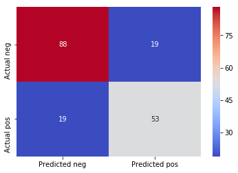

```python
_=sns.heatmap(confusion_asg, cmap='coolwarm', annot=True)
```

## Calculate Area Under the ROC curve and Obtain The Optomal Cut Off point

```python
from sklearn.metrics import roc_curve, roc_auc_score
```

```python
probs = final_model.predict(X_test)
```

```python
auc = roc_auc_score(Y_test, probs)
```

```python
auc
```

```
0.8529335410176532
```

```python
fpr, tpr, threshold = roc_curve(Y_test, probs)
```

#### Plot ROC Curve

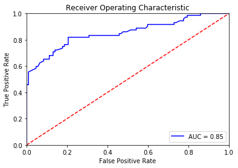

```python
plt.title('Receiver Operating Characteristic')
plt.plot(fpr, tpr, 'b', label = 'AUC = %0.2f' % auc)
plt.legend(loc = 'lower right')
plt.plot([0, 1], [0, 1],'r--')
plt.xlim([0, 1])
plt.ylim([0, 1])
plt.ylabel('True Positive Rate')
plt.xlabel('False Positive Rate')
plt.show()
```

#### Find the optimal cut off threshold

```python
optimal_idx = np.argmax(tpr - fpr)
optimal_threshold = threshold[optimal_idx]
```

```python
optimal_threshold
```

```
0.32851427304275294
```

## Updata model based on optimal probability threshold

```python
new_predictions = np.where(probs>optimal_threshold, 1, 0)
```

```python
new_confusion_mat = confusion_matrix(Y_test, new_predictions)
```

```python
new_confusion_asg = pd.DataFrame(new_confusion_mat, index=['Actual neg','Actual pos'],
                                 columns=['Predicted neg','Predicted pos'])
```

```python
new_confusion_asg
```

|  | Predicted neg | Predicted pos |
| --- | --- | --- |
| Actual neg | 85 | 22 |
| Actual pos | 14 | 58 |

```python
from sklearn.metrics import accuracy_score
```

```python
accuracy_score(Y_test, new_predictions)
```

```
0.7988826815642458
```

We can see accuracy increased . Hence model improved .